# ‘You Draw It’ – Example

**Summary:** Simple RShiny application example for the ‘You Draw It’ feature.

‘You Draw It’ is a feature that allows users to interact with a chart directly by drawing a line on their computer screen with a mouse. Originally introduced by the [New York Times](https://www.nytimes.com/interactive/2015/05/28/upshot/you-draw-it-how-family-income-affects-childrens-college-chances.html) in 2015 for the purpose of interactive reading, we aimed to adapt and demonstrate the use of the ‘You Draw It’ method as a tool for interactive testing of graphics.

Test out the development applet [here](https://emily-robinson.shinyapps.io/can-you-draw-it/).

## Getting Started with D3.js

*Note: Source code written in [D3.js version 5](https://devdocs.io/d3~5/).*

`D3.js` is to JavaScript as `ggplot2` is to R

- [Codecademy: Introduction to JavaScript](https://www.codecademy.com/learn/introduction-to-javascript)
- Understand [SVG](http://tutorials.jenkov.com/svg/g-element.html) elements: inspect elements in web browser!
- Amelia Wattenberger’s [Full Stack D3 and Data Visualization Book](https://www.newline.co/fullstack-d3)
- Build a basic graphic using [r2d3](https://rstudio.github.io/r2d3/articles/introduction.html)
- Modify `D3.js` code until it does what you want!

**Additional Resources**

- [How to learn D3 with no coding experience](https://www.heshameissa.com/blog/learn-d3)
- [Kiegan’s ISU Graphics Group Presentation from Mar 25, 2021](https://kiegan.github.io/talks/graphics-group-r2d3/graphics-group-r2d3.html#1)
- Amelia Wattenberger on [Twitter](https://twitter.com/Wattenberger)

## Getting Started with RShiny App Development

- [Mastering Shiny](https://mastering-shiny.org/) by Hadley Wickham
- [Blog: The Best Resources for Learning Shiny App Development](https://www.r-bloggers.com/2021/04/the-best-resources-for-learning-shiny-app-development/)

## Code Sketch

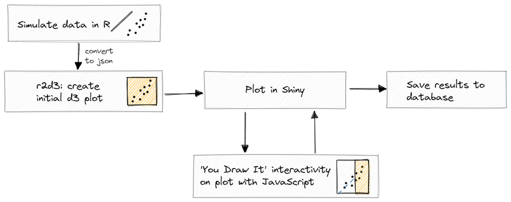